# Probabilistic pseudotime inference using Bayesian Gaussian Process Latent Variable Models

Kieran Campbell

2017-10-06

## Introduction

`pseudogp` fits probabilistic pseudotime trajectories to two-dimensional reduced-dimension representations of genomic data using Bayesian Gaussian Process Latent Variable Models. Under the hood it uses [Stan](http://mc-stan.org) for posterior inference, and provides a few useful functions for plotting the resulting traces (notably `posteriorCurvePlot` and `posteriorBoxPlot`).

## A simple example

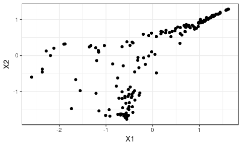

```r
library(pseudogp)
library(ggplot2)
data(monocle_le)

ggplot(data.frame(monocle_le)) + geom_point(aes(x = X1, y = X2)) + theme_bw()
```

Then we can do a simple fit using the `fitPseudotime` function provided by `pseudogp`:

```r
le_fit <- fitPseudotime(monocle_le, smoothing_alpha = 30, smoothing_beta = 6, iter = 1000, chains = 1)
```

However, this takes a long time for a vignette, so we can use the `le_fit` example bundled with the package as our reference:

```r
data(le_fit)
```

We can plot the posterior curve in the reduced space:

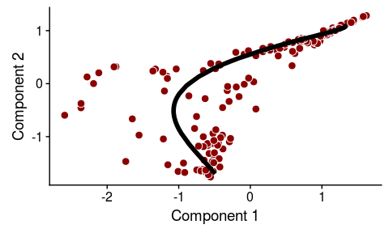

```r
posteriorCurvePlot(monocle_le, le_fit)
```

we can plot individual traces by setting `posterior_mean = FALSE`:

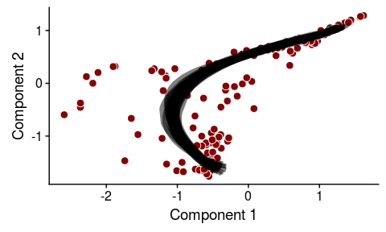

```r
posteriorCurvePlot(monocle_le, le_fit, posterior_mean = FALSE)
```

and we can visualise the uncertainty using a boxplot

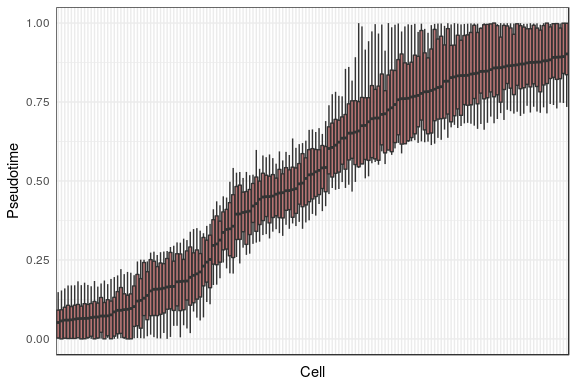

```r
posteriorBoxplot(le_fit)
```

## Exracting posterior samples from the `stanfit` object

All the posterior samples of pseudotime and kernel parameters are contained in the object returned by `rstan::stan`. We can use `rstan`’s built in plotting functions to examine the traces of the kernel parameters too. For example, we can look at a boxplot of the lambda parameters or plot the trace of the sigma (noise) parameters:

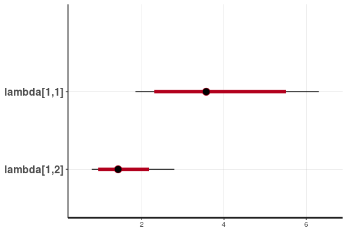

```r
rstan::plot(le_fit, pars="lambda")
```

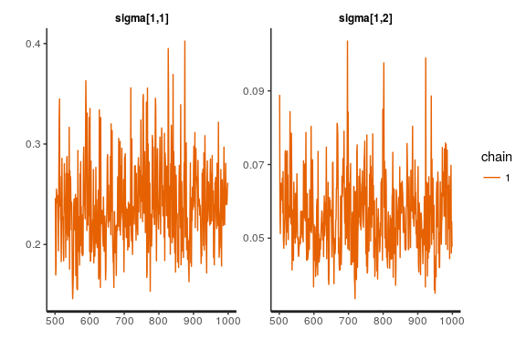

```r
rstan::traceplot(le_fit, pars="sigma")
```

We can also extract the pseudotime traces from the object using `rstan:extract`:

```r
pst <- rstan::extract(le_fit, pars="t")$t
print(str(pst))
```

```
##  num [1:500, 1:155] 0.1106 0.1466 0.09 0.0906 0.0164 ...
##  - attr(*, "dimnames")=List of 2
##   ..$ iterations: NULL
##   ..$           : NULL
## NULL
```

We can then use `ggplot2` to plot posterior distributions to get a handle on the uncertainty:

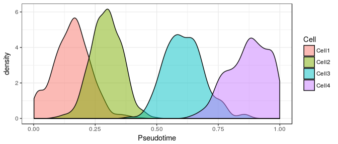

```r
set.seed(1L)
to_sample <- sample(nrow(monocle_le), 4)
traces <- data.frame(pst[,to_sample])
names(traces) <- paste0("Cell",1:4)
traces_melted <- reshape2::melt(traces, variable.name="Cell", value.name="Pseudotime")
pstplt <- ggplot(traces_melted) + geom_density(aes(x = Pseudotime, fill = Cell), alpha = 0.5) +
  theme_bw()
pstplt
```

We can also find the MAP pseudotime estimates using the `posterior.mode` function from the `MCMCglmm` package:

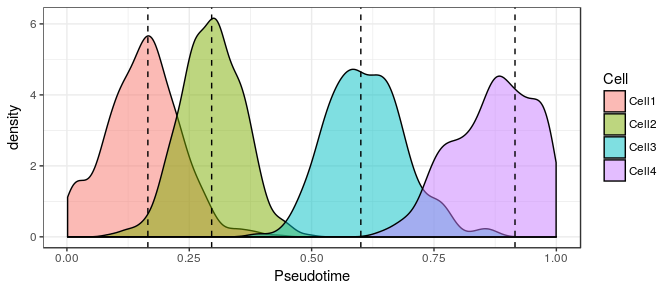

```r
library(MCMCglmm)
library(coda)
tmcmc <- mcmc(traces)
tmap <- posterior.mode(tmcmc)
for(i in 1:length(tmap)) {
  pstplt <- pstplt + geom_vline(xintercept = tmap[i], linetype = 2)
}
pstplt
```

## Choice of reduced dimension representation

Gaussian Process Latent Variable Models are brilliant, but not magic. There needs to be some structure in the representation you choose to get a consistent curve fit. Let’s look at an example of a representation with ‘structure’ and one without.

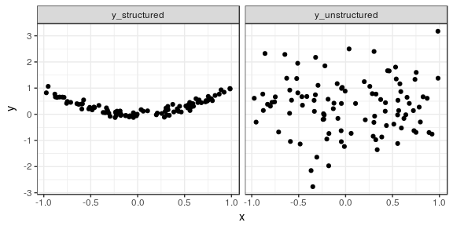

```r
x <- runif(100, -1, 1)
y_structured <- rnorm(100, x^2, sd = 0.1)
y_unstructured <- rnorm(100, x^2, sd = 1)
dfplt <- data.frame(x, y_structured, y_unstructured)
dfmelt <- reshape2::melt(dfplt, id.vars = "x", value.name = "y")
ggplot(dfmelt) + geom_point(aes(x=x, y=y)) + facet_wrap(~variable) + theme_bw()
```

This method will consistently fit the structured data, but not the unstructured. To test for ‘consistency’, call `fitPseudotime` with multiple chains (by using the `chains` parameter) and then plot the posterior curves (`posteriorCurvePlot` automatically handles multiple chains and colours each differently). If the curves from each chain line up then you have a consistent fit. If not, look to a different representation of your data or select genes to encourage structure.

## Fitting to multiple reduced dimensional representations simultaneously

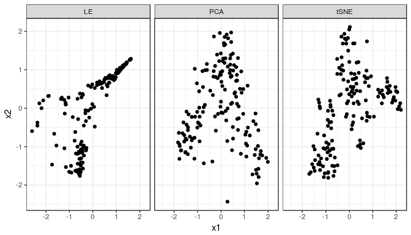

```r
## first let's load the data
data(monocle_le)
data(monocle_pca)
data(monocle_tsne)

X <- data.frame(rbind(monocle_le, monocle_pca, monocle_tsne))
names(X) <- c("x1", "x2")
X$cell <- rep(1:nrow(monocle_le), times = 3)
X$representation <- rep(c("LE", "PCA", "tSNE"), each = nrow(monocle_le))
ggplot(X) + geom_point(aes(x = x1, y = x2)) + facet_wrap( ~ representation) + theme_bw()
```

Now we can prepare data and call the stan fit. This is left unevaluated here due to the significant runtime. However, all plotting functions can be called as before.

```r
data <- list(LE = monocle_le, PCA = monocle_pca, tSNE = monocle_tsne)
fit <- fitPseudotime(data, chains = 2, iter = 1000, smoothing_alpha = 12, smoothing_beta = 3)
```

## Technical details

[output not shown]

[output cut: 25 more lines]

[output not shown]